# Ford Gobike Trip Data Analysis

## by Eman Khalaf

## Workflow of the analysis

### Overview about the project and the dataset

- Here, we will be exploring the trip data of the Ford gobike rental system.
- At the beginning, we will perform initial assessment through checking the shape and composition of the data.
- Then, we will be cleaning the data accordingly.
- Eventually, we will be picking up variables that look important for the data analysis and extract them into a new dataframe.

### Data Exploration

- Univariate Exploration
- Bivariate Exploration
- Multivariate Exploration

### Key Findings and Conclusions

## What is the structure of your dataset?

- The data contain 183412 records for bike trips with 16 features/variables (duration_sec, start_time, end_time, start_station_id, start_station_name, start_station_latitude, start_station_longitude, end_station_id, end_station_name, end_station_latitude ,end_station_longitude, bike_id, user_type, member_birth_year, member_gender, bike_share_for_all_trip). 9 out of the 16 features are numerical, whereas 7 are of object type. There are missing values in start_station_id, start_station_name, end_station_id, end_station_name, member_birth_year, and member_gender variables, however, there are no duplicates.

# What is/are the main feature(s) of interest in your dataset?

From data exploation, I found 8 interesting features to focus on through out the analyses. These variables are:

- Average trip duration
- Most common weekday for renting bikes
- Most common day hour for renting bikes
- The most common age group using Gobike rental service
- The most common gender that uses Gobike rental service
- Impact of user_type
- Impact of bike_share_for_all_trip variable on bike trips
- Most common start_station_name

# What features in the dataset do you think will help support your investigation into your feature(s) of interest?

- I expect weekday, week hour, gender, and age, user_type are the major features influencing the rental rates of Gobike service.

#### I'll start by looking at the duration of bike trips across the dataset.

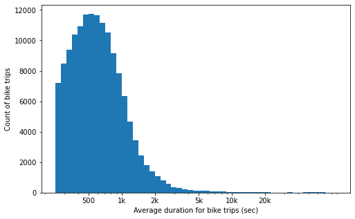

#### Let us check the pattern of hourly sharing bikes according to member gender

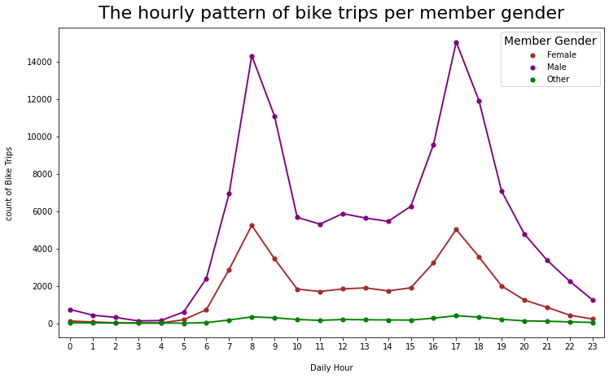

#### Let us test the pattern of weekly usage of Gobike service according to the age_group

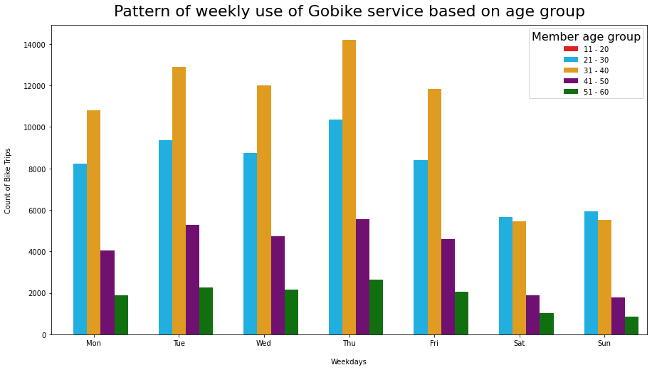

- From the clustered bar plot above, we noticed that members in age group 31-40 are the most frequent users of the service across the week days except for the weekend, where members in age group 21-30 have a little bit higher rate. Regarding other groups, the rate is relatively consistent across the week days.

#### Distribution of bike trips' count across most frequent start_stations

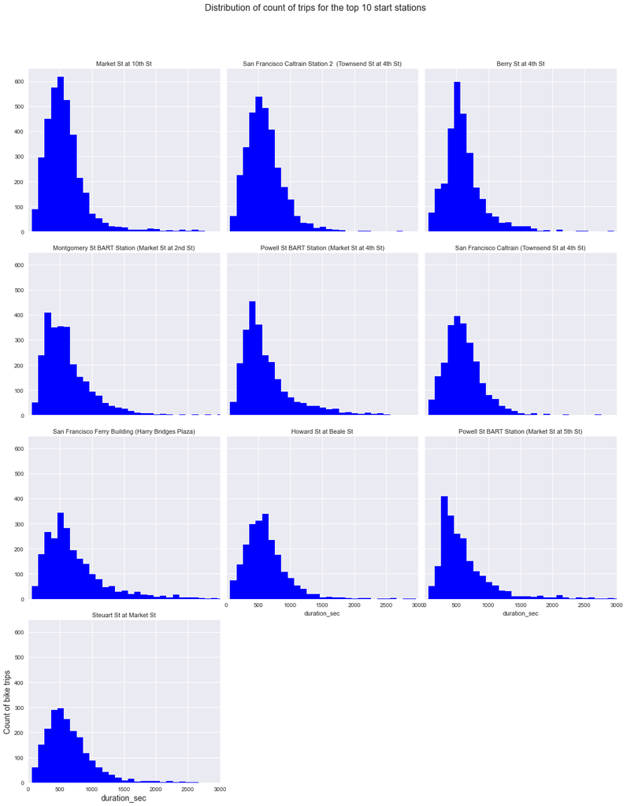

#### Let us explore the relationship between user type, trip durtion and possibility of bike share all the trip

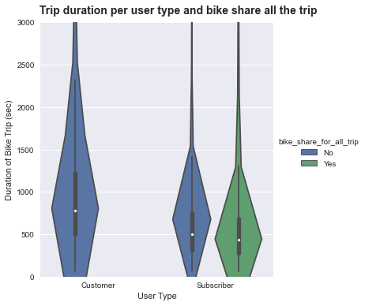

- From the violin plot above, we noticed that only subscribers may or may not share the bike for all the trip, but all customers do not. In addition, most subscribers share the bike for all the trip for shorter durations compared to those who do not from the same group (subscribers).

#### Let us explore the pattern of the relationship across subscribers (constitute the majority of users), age group, and daily hours during the entire week

- I will be performing this task through adapting heatmaps

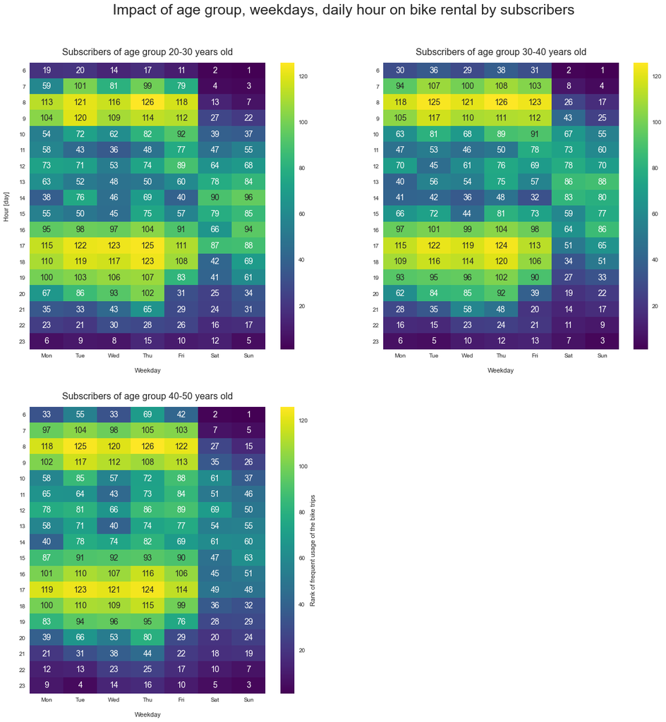

- Interestingly, when spanning the heatmaps of the 3 calculated age groups, we noticed a strong consistent correlation pattern across all of the heatmaps where the peak maximum of bike rental was at 8 am, and 5 pm on Thursday followed by Tuesday regardless to the age group. Additionally, weekends showed the lowest usage of the service for all age groups.

# Key findings and conclusions